# Final Project: Commuting Networks & Displacement

## Gentrification and Network Centrality Across NYC's Five Boroughs

**Course:** DATA 620 — Web Analytics  
**Student:** Sheriann McLarty  
**GitHub:** DATA620_WebAnalytics_SheriannMc  
**Primary Data:** Census LODES 2021, ACS 5-Year 2021, NYC 311 Service Requests, NYC DCP NTA Crosswalk, NYC PLUTO, MTA Subway Station Locations

## Abstract

This project examines whether gentrification, displacement pressure, and long-term disinvestment are reflected in the structure of New York City's commuting network. Using 2021 Census LODES origin-destination employment data, I construct a directed, weighted tract-to-tract commuting network for the five boroughs of New York City. Census tracts function as nodes, and commuting flows from home tracts to work tracts function as directed edges. I then merge network measures with tract-level socioeconomic indicators from the American Community Survey to classify tracts into gentrification-related stages.

The analysis incorporates two major themes from DATA 620: network analysis and text processing. The network analysis compares in-degree centrality, out-degree centrality, eigenvector centrality, weighted in-strength, and weighted out-strength across gentrification stages. The text-processing component uses NYC 311 complaint descriptions and complaint categories to examine whether housing distress and quality-of-life language differ by neighborhood stage.

## Research Question

Do census tracts experiencing gentrification, displacement pressure, or long-term disinvestment occupy significantly different positions in New York City's internal commuting network than stable, moderate, or affluent tracts?

## Hypothesis

I hypothesize that gentrifying and affluent tracts will show stronger in-degree centrality because they may function as employment, commercial, or institutional destinations. I also hypothesize that displaced, at-risk, and deeply disinvested tracts will show stronger out-degree centrality because residents in these areas may commute outward to a wider range of work destinations.

This final project extends my earlier Brooklyn-only commuting network analysis by expanding the geography to all five NYC boroughs and replacing a binary poverty classification with a multi-stage gentrification and displacement framework.

## Reproducibility Note

The notebook is designed to run in Google Colab. It downloads public datasets directly from Census, NYC Open Data, NYC Department of City Planning, and MTA sources. Some API calls may take several minutes depending on network speed and public data-server availability.

## 1. Environment Setup

This section loads the Python libraries used for data retrieval, network construction, spatial analysis, visualization, statistical testing, and text processing. The workflow uses `networkx` for graph construction and centrality measures, `geopandas` for spatial joins and mapping, `scipy` for non-parametric statistical testing, and `wordcloud`/`scikit-learn` for the 311 complaint text analysis.

The code installs any required packages that may not already be available in a fresh Colab runtime.

```
Libraries loaded.
Stage color palette: ['High Displacement Risk', 'Gentrifying', 'Stable Moderate', 'Stable Affluent', 'Deeply Disinvested', 'Unknown']
```

## 2. LODES Origin-Destination Data

The main network dataset comes from the U.S. Census Bureau's LEHD Origin-Destination Employment Statistics (LODES). LODES records home-to-work flows at the census block level. For this project, I use the 2021 New York main jobs origin-destination file and later aggregate block-level flows to census tract-level flows.

This dataset is appropriate for the research question because it captures the direction of commuting movement: from where workers live to where they work. That directionality allows the analysis to distinguish between residential tracts that send workers outward and destination tracts that receive workers.

```
Downloading LODES OD file (may take 1-2 minutes)...
LODES loaded: 7,144,618 rows
```

## 3. Geographic Crosswalk and NYC Filtering

The LODES file is reported at the census block level, so I use the LODES geographic crosswalk to map each home and work block to its corresponding census tract and county. The analysis is limited to the five NYC counties: Bronx, Brooklyn, Manhattan, Queens, and Staten Island.

This filtering decision keeps the project focused on NYC's internal commuting network. Flows to New Jersey, Long Island, Westchester, and other regional destinations are excluded, which is addressed later as a limitation.

```
Downloading crosswalk...
NYC census blocks: 37,984
```

## 4. Tract-to-Tract Network Edge Construction

After assigning home and work blocks to census tracts, I aggregate the data into tract-to-tract commuting flows. Each row in the resulting edge list represents a directed connection from a home tract to a work tract, and the edge weight is the number of commuters traveling between those two tracts.

This produces the core network structure used throughout the project.

```
NYC-internal OD flows (block level): 2,466,029
Tract-to-tract edges: 985,216
```

|  | home_tract | work_tract | weight |
| --- | --- | --- | --- |
| 0 | 36005000100 | 36005001903 | 1 |
| 1 | 36005000100 | 36005005100 | 1 |
| 2 | 36005000100 | 36005007600 | 1 |
| 3 | 36005000100 | 36005012102 | 1 |
| 4 | 36005000100 | 36005014100 | 1 |

## 5. ACS Socioeconomic Data

To connect commuting structure to neighborhood conditions, I pull tract-level American Community Survey indicators for poverty, rent burden, median household income, and educational attainment. These variables are used to classify census tracts into gentrification-related stages.

The classification is not intended to replace an official longitudinal gentrification index. Instead, it provides a reproducible cross-sectional grouping that allows centrality measures and complaint patterns to be compared across different socioeconomic conditions.

```
Pulling ACS subject table (poverty)...
Pulling ACS detail tables (rent, income, education)...
ACS tracts pulled: 2327
```

## 6. Gentrification and Displacement Stage Classification

This section derives a tract-level classification using ACS indicators. The categories are:

- **High Displacement Risk:** high poverty and high severe rent burden.
- **Gentrifying:** high college attainment and high rent burden, but not in the highest poverty quartile.
- **Stable Moderate:** tracts that do not meet the more extreme criteria.
- **Stable Affluent:** high income, low poverty, and low rent burden.
- **Deeply Disinvested:** very high poverty and low income.

This framework allows the project to move beyond a simple high-poverty vs. low-poverty comparison and examine whether different forms of neighborhood pressure map onto different commuting-network positions.

```
Gentrification stage distribution:
gentrification_stage
Stable Moderate           1511
Deeply Disinvested         397
Stable Affluent            198
Unknown                    135
High Displacement Risk      48
Gentrifying                 38
Name: count, dtype: int64

Stage by borough:
gentrification_stage  Deeply Disinvested  Gentrifying  High Displacement Risk  \
borough
Bronx                                179            2                       6
Brooklyn                             129           15                      28
Manhattan                             53            8                       3
Queens                                30           12                       9
Staten Island                          6            1                       2

gentrification_stage  Stable Affluent  Stable Moderate  Unknown
borough
Bronx                               5              147       22
Brooklyn                           59              537       37
Manhattan                          49              184       13
Queens                             60              560       54
Staten Island                      25               83        9
```

## 7. Optional DRI Context

NYC's Displacement Risk Index was explored as a possible validation or supplemental data source. However, the primary classification used in this notebook is the ACS-derived framework above because it is transparent, reproducible, and directly connected to the variables used in the analysis.

```
NYC DRI loaded: 2327 rows
Using ACS classification as primary (reproducible, no third-party dependency).
```

## 8. Directed Weighted Network Construction

The tract-to-tract commuting edge list is converted into a directed weighted graph. In this graph:

- Nodes represent census tracts.
- Directed edges represent commuting flows from home tract to work tract.
- Edge weights represent the number of commuters.

The directed structure is analytically important because incoming and outgoing connections have different meanings. In-degree centrality captures the extent to which a tract receives workers, while out-degree centrality captures how broadly residents of a tract commute outward.

```
Graph: 2325 nodes, 985,216 edges
Stage distribution: Counter({'Stable Moderate': 1511, 'Deeply Disinvested': 397, 'Stable Affluent': 198, 'Unknown': 133, 'High Displacement Risk': 48, 'Gentrifying': 38})
Borough distribution: Counter({'Brooklyn': 804, 'Queens': 725, 'Bronx': 361, 'Manhattan': 310, 'Staten Island': 125})
```

## 9. Network Descriptive Statistics

Before calculating centrality measures, I summarize the overall structure of the five-borough commuting network. Network size, density, connectivity, and total commuter volume provide context for interpreting the later centrality results.

This step also allows comparison with my earlier Brooklyn-only project. Expanding from Brooklyn to all five boroughs changes the scale of the network and can affect density and centrality distributions.

```
=== Five-Borough Network Descriptives ===
Nodes:                2325
Edges:                985,216
Density:              0.1823
Weakly connected:     True
Nodes in LWCC:        2325
Total commuters:      2,826,641

--- Comparison to Project 1 ---
Project 1 (Brooklyn only): ~800 nodes, density ~0.237
This project (5 boroughs): 2325 nodes, density 0.1823
```

## 10. Centrality Measures

This project uses multiple centrality measures because no single network metric captures the full meaning of tract position in an urban commuting network.

- **In-degree centrality** measures how many distinct home tracts send workers into a tract.
- **Out-degree centrality** measures how many distinct work tracts residents commute to from a tract.
- **Weighted in-strength** measures total commuter inflow.
- **Weighted out-strength** measures total commuter outflow.
- **Eigenvector centrality** measures whether a tract is connected to other highly connected tracts.

The distinction between degree centrality and weighted strength is important. Degree centrality captures the number of distinct connections, while weighted strength captures commuter volume.

```
Computing degree centrality...
Computing weighted strength...
Computing eigenvector centrality (LWCC)...
EVC converged on directed LWCC.
EVC method: directed
node_df shape: (2325, 12)
Mean by stage:
```

| gentrification_stage | in_degree_centrality | out_degree_centrality | in_strength | out_strength |
| --- | --- | --- | --- | --- |
| Deeply Disinvested | 0.1771 | 0.2054 | 930.1134 | 1292.0403 |
| Gentrifying | 0.2466 | 0.1720 | 1734.2895 | 1249.8947 |
| High Displacement Risk | 0.1630 | 0.1841 | 802.0417 | 1161.6667 |
| Stable Affluent | 0.2292 | 0.1734 | 1805.2778 | 1442.0152 |
| Stable Moderate | 0.1774 | 0.1876 | 1212.1185 | 1250.8054 |
| Unknown | 0.1729 | 0.0691 | 1233.3008 | 262.8496 |

## 11. Neighborhood Labels for Interpretation

Census tract identifiers are precise but difficult to interpret in a presentation or report. To make the results more readable, I use the NYC Department of City Planning NTA crosswalk to map census tracts to neighborhood names.

This step supports the later neighborhood-level charts, which translate tract-level network results into more recognizable geographic areas.

```
DCP Excel failed (HTTP Error 403: Forbidden). Trying Socrata fallback...
NTA loaded via Socrata: 2327 rows
Tracts with neighborhood name: 2325
```

## 12. Statistical Testing Strategy

Because network centrality measures are often skewed and may not meet normality assumptions, I use the Kruskal-Wallis test to compare centrality distributions across the five gentrification stages. Kruskal-Wallis is a non-parametric alternative to one-way ANOVA and is appropriate when comparing more than two independent groups.

The test evaluates whether at least one gentrification stage differs from the others for each network measure. A statistically significant result does not prove causation, but it indicates that the distribution of a given centrality measure differs across stages.

```
=== Kruskal-Wallis Test Results (5 Gentrification Stages) ===
Metric                            H statistic      p-value  Significant
------------------------------------------------------------------------
In-Degree Centrality                    17.51       0.0015          YES
Out-Degree Centrality                   85.33       0.0000          YES
Eigenvector Centrality                  25.15       0.0000          YES
Weighted In-Strength                    16.43       0.0025          YES
Weighted Out-Strength                   17.04       0.0019          YES
```

## 13. Centrality Distributions by Stage

The boxplots visualize how each centrality measure varies across gentrification stages. This figure helps identify whether differences are concentrated in a specific measure, such as out-degree centrality, or whether the pattern appears across multiple measures.

The central analytic question is whether displacement and disinvestment are more visible through outbound commuting dispersion than through traditional destination-based centrality.

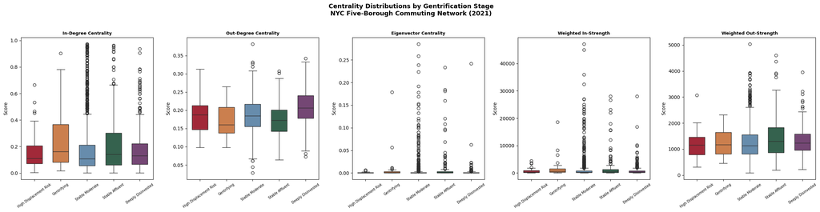

```
Saved: centrality_by_stage_boxplots.png
```

## 14. Rent Burden and Out-Degree Centrality

This scatterplot examines whether severe rent burden is directly associated with out-degree centrality. The trend line is used descriptively, not as a causal model.

A weak or uneven trend would suggest that rent burden alone does not fully explain outbound commuting dispersion. This is useful because commuting patterns are likely shaped by multiple overlapping factors, including housing costs, job location, transit access, wages, and local employment structure.

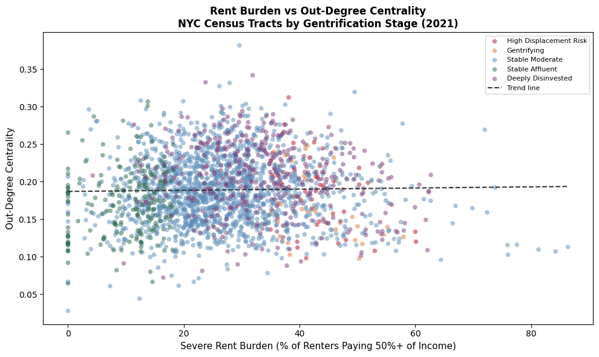

```
Trend line slope: 0.000076 per 1% increase in rent burden
```

## 15. Neighborhood-Level In-Degree Hubs

To interpret destination-oriented centrality, I aggregate tract-level in-degree centrality to neighborhood areas. This chart identifies the top in-degree neighborhoods within each borough.

High in-degree centrality often reflects employment, commercial, airport, or institutional destinations rather than residential displacement pressure. This distinction helps explain why in-degree and out-degree centrality should not be interpreted as measuring the same urban process.

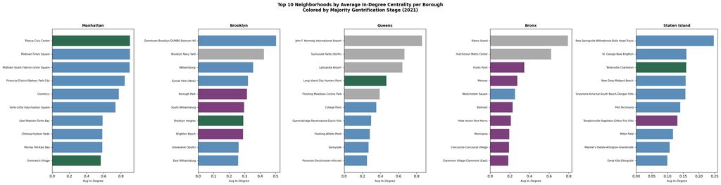

```
Saved: top10_neighborhoods_per_borough.png
```

## 16. Spatial Visualization of Stage and Out-Degree

Spatial visualization is used to compare the geography of gentrification stage with the geography of outbound commuting dispersion. The first choropleth maps the ACS-derived gentrification stages, while the second maps out-degree centrality.

These maps are important because the project is not only asking whether centrality differs statistically; it is also asking whether the patterns have a meaningful spatial structure across the five boroughs.

```
Downloading NYC census tract shapefile...
Shapefile: 2326 NYC tracts
Matched to node_df: 2325
```

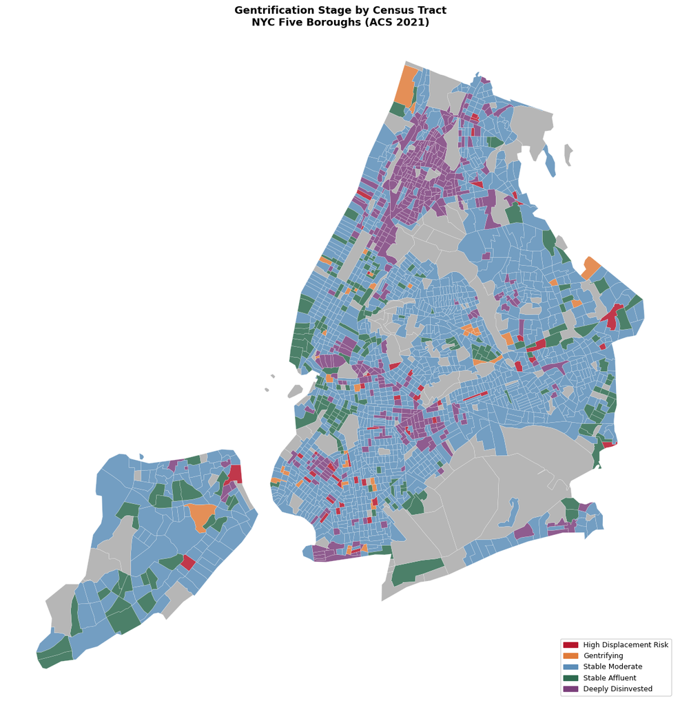

```
Saved: choropleth_gentrification_stage.png
```

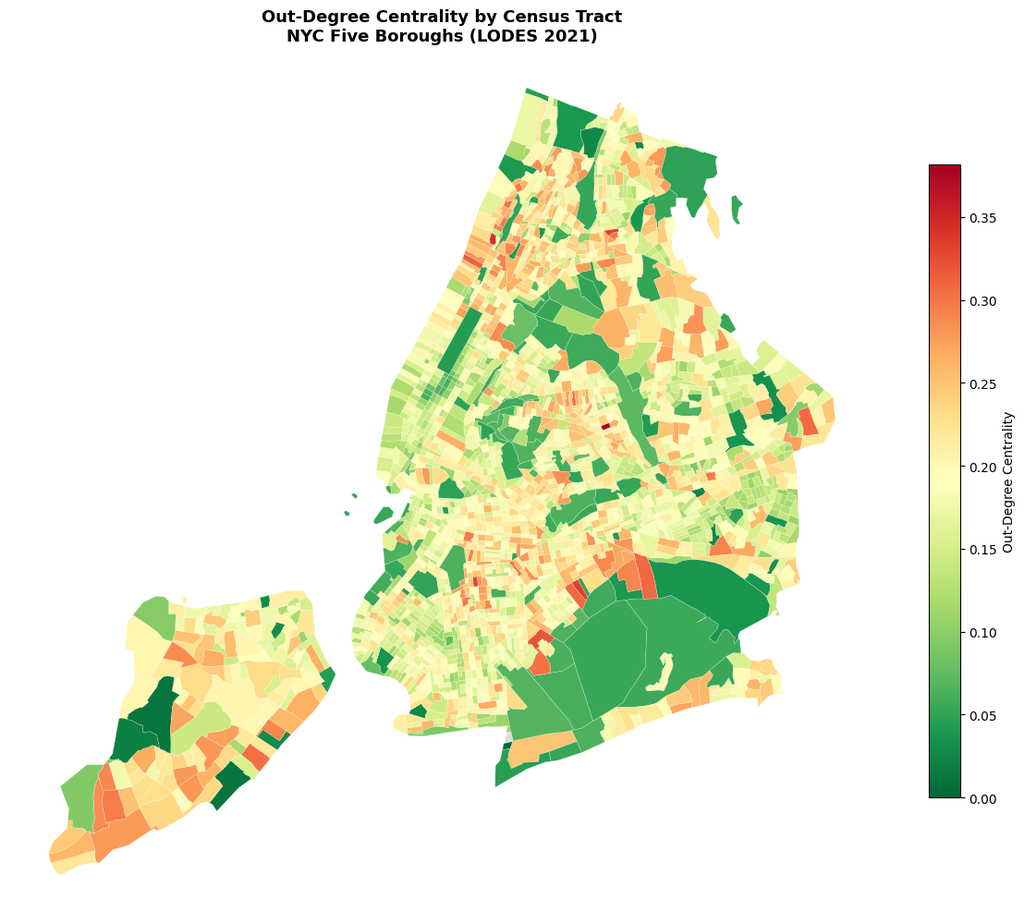

```
Saved: choropleth_out_degree.png
```

## 17. Interactive Map

The interactive Folium map allows tract-level exploration of gentrification stage, out-degree centrality, in-degree centrality, rent burden, and poverty rate. This map supports reproducibility and allows the reader to inspect individual tracts rather than relying only on static figures.

```
Interactive map saved: nyc_commuting_gentrification_map.html
```

[interactive chart not shown]

## 18. Supplemental Housing Context: NYCHA

NYCHA public housing data is used as supplemental context for understanding where public housing developments fall within the gentrification-stage framework. This section is exploratory and is interpreted cautiously because public housing geography reflects policy history, land use, and neighborhood development decisions that require deeper historical analysis beyond the scope of this notebook.

```
Loading NYCHA development data...
NYCHA developments loaded: 216
Could not find lat/lon columns. Available: ['the_geom', 'developmen', 'tds_num', 'borough']
```

## 19. Supplemental Building Context: PLUTO

PLUTO building data adds physical neighborhood context by examining building age, residential units, and assessed property values. These indicators help connect the 311 housing complaint patterns to the built environment.

The PLUTO analysis is not the primary evidence for the network findings, but it helps explain why older and lower-valued building stock may be associated with higher levels of housing distress complaints.

```
Loading PLUTO building data (this may take a minute)...
PLUTO records loaded: 50,000
Buildings matched to tracts: 49,845

Median year built by stage:
gentrification_stage
Deeply Disinvested        1920.0
Gentrifying               1922.5
High Displacement Risk    1925.0
Stable Moderate           1930.0
Stable Affluent           1935.0
Unknown                   2009.0

Share pre-1950 by stage:
gentrification_stage
High Displacement Risk    74.9%
Deeply Disinvested        73.3%
Stable Moderate           71.3%
Gentrifying               65.4%
Stable Affluent           59.1%
Unknown                   19.3%

Median assessed value by stage:
gentrification_stage
Deeply Disinvested         $85,920
Gentrifying               $329,715
High Displacement Risk     $84,900
Stable Affluent            $79,440
Stable Moderate            $73,380
Unknown                    $50,880
```

## 20. NYCHA and PLUTO Visualization

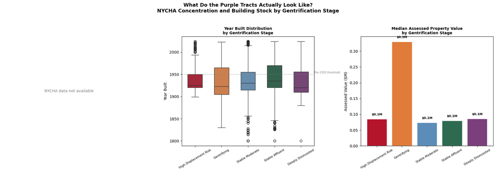

```
Saved: nycha_pluto_by_stage.png
```

## 21. NYCHA Overlay Map

```
NYCHA data not available -- run in Colab to generate this map.
```

## 22. Supplemental Housing Summary

[output not shown]

## 23. Transit Access

Transit access is measured as the distance from each census tract centroid to the nearest subway station. This measure adds context to the commuting network because outbound commuting dispersion may carry different burdens depending on how accessible public transit is from a tract.

Distance to subway is not a complete measure of transit quality, but it provides a tract-level approximation of subway proximity.

```
Loading MTA subway station data...
MTA stations loaded: 496
Computing nearest subway station distance for each tract...

Average distance to nearest subway station by stage:
                         mean  median
gentrification_stage
Unknown                 1.021   0.701
Stable Affluent         0.927   0.442
Stable Moderate         0.672   0.349
Gentrifying             0.615   0.328
High Displacement Risk  0.531   0.245
Deeply Disinvested      0.338   0.251

Kruskal-Wallis on subway access: H=61.3457, p=0.0000, Significant: YES
```

## 24. Rent Change Over Time

To add temporal housing context, this section compares median gross rent in 2015 and 2021. This helps identify whether some tract categories experienced larger rent increases over time.

This is not a full longitudinal gentrification model, but it adds a useful temporal indicator to supplement the cross-sectional ACS classification.

```
Pulling ACS median rent 2015...
Pulling ACS median rent 2021...

Median rent change 2015→2021 by gentrification stage:
                        rent_2015  rent_2021  rent_change_dollar  rent_change_pct
gentrification_stage
Gentrifying                1353.0     1760.5               384.0             28.4
High Displacement Risk     1285.0     1639.0               354.0             28.1
Unknown                    1237.0     1561.0               353.0             27.7
Stable Affluent            1741.0     2245.5               470.0             27.2
Stable Moderate            1337.0     1686.0               340.0             25.2
Deeply Disinvested         1008.0     1217.0               220.5             22.3

Kruskal-Wallis on rent change: H=9.3956, p=0.0519, Significant: NO
```

## 25. Commute-Time Burden

The ACS commute-time variables are used to calculate the share of workers in each tract with commutes of 30 minutes or longer. This provides another way to interpret outbound commuting dispersion.

Out-degree centrality measures the number of distinct work destinations, while commute-time burden measures the time cost associated with travel to work.

```
Pulling ACS commute time data...

Long commute rate (30+ min) by gentrification stage:
                        mean  median
gentrification_stage
Deeply Disinvested      73.4    75.0
High Displacement Risk  71.6    74.1
Stable Moderate         71.2    73.4
Unknown                 69.7    75.4
Gentrifying             67.7    71.5
Stable Affluent         63.9    67.3

Kruskal-Wallis on long commute rate: H=58.6864, p=0.0000, Significant: YES

Spearman r (Out-Degree vs Long Commute): r=0.2412, p=0.0000
Significant positive correlation -- broader commuting range = more time spent commuting.
```

## 26. Triple Burden Analysis

The triple-burden figure compares three indicators by gentrification stage: distance to subway, rent change, and the share of workers with commutes of 30 minutes or more.

This section helps interpret the network findings in a broader urban context. If a tract has high outbound commuting dispersion, rising rents, longer commute times, and weaker transit access, then commuting centrality becomes part of a larger pattern of neighborhood burden.

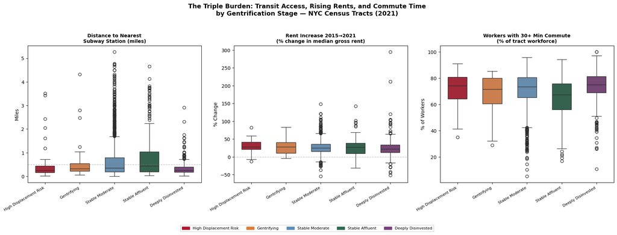

```
Saved: triple_burden_by_stage.png
```

## 27. Triple Burden Summary

This summary prints the average transit-distance, rent-change, and commute-time values by gentrification stage. These summaries are used to support the interpretation of the triple-burden chart.

[output not shown]

## 28. 311 Complaint Data and Text-Processing Design

To incorporate the text-processing theme of DATA 620, this project uses NYC 311 complaint data from 2023. Complaint types and descriptors are grouped into two broad categories: housing distress and quality-of-life complaints.

Housing distress includes complaints such as heat, hot water, mold, plumbing, paint, pests, and landlord-related issues. Quality-of-life complaints include noise, illegal parking, blocked driveways, graffiti, sanitation, and street conditions.

This approach treats 311 complaint language as a descriptive civic-data signal. It does not capture every underlying neighborhood condition, but it allows the project to compare reported issues across gentrification stages.

```
Pulling housing distress complaints...
  Housing complaints: 50,000
Pulling quality-of-life complaints...
  QoL complaints: 50,000

Total complaints with coordinates: 100,000
complaint_type
HEAT/HOT WATER             43511
Illegal Parking            20715
Noise - Residential        11795
Blocked Driveway            5709
Noise - Street/Sidewalk     5523
Elevator                    4137
Street Condition            2683
Noise - Commercial          2180
Lead                        1751
Sidewalk Condition           943
Plumbing                     545
Graffiti                     452
Mold                          56
Name: count, dtype: int64
```

## 29. Spatial Join of 311 Complaints to Census Tracts

The 311 complaints are converted to point geometries using latitude and longitude, then spatially joined to census tracts. This step makes it possible to connect complaint language and complaint categories to the same tract-level gentrification stages used in the network analysis.

```
Running spatial join (this may take a minute)...
Complaints matched to tracts: 99,994

Complaints by stage:
gentrification_stage
Stable Moderate           60941
Deeply Disinvested        27748
Stable Affluent            6240
High Displacement Risk     2492
Gentrifying                1412
Unknown                    1161
Name: count, dtype: int64

Complaints by category and stage:
category                Housing Distress  Quality of Life
gentrification_stage
Deeply Disinvested                 16722            11026
Gentrifying                          705              707
High Displacement Risk              1381             1111
Stable Affluent                     2026             4214
Stable Moderate                    28810            32131
Unknown                              355              806
```

## 30. Housing Distress Rate by Tract

After joining complaints to tracts, I calculate the share of each tract’s complaints that fall into the housing distress category. This produces a tract-level housing distress rate that can be compared across gentrification stages.

A Kruskal-Wallis test is also used here to evaluate whether the housing distress rate differs across stages.

```
Mean housing distress rate by stage:
                        housing_rate  housing   total
gentrification_stage
Deeply Disinvested             0.500   42.121  69.894
Gentrifying                    0.424   18.553  37.158
Stable Moderate                0.355   19.105  40.412
High Displacement Risk         0.337   28.771  51.917
Stable Affluent                0.303   10.284  31.675
Unknown                        0.164    3.413  11.163

Kruskal-Wallis on Housing Distress Rate:
H=106.4795, p=0.0000, Significant: YES
```

## 31. Complaint Patterns by Stage

This visualization compares both the distribution of housing distress complaint rates and the overall complaint mix by gentrification stage. The left panel shows tract-level variation, while the stacked bar chart shows the percentage of complaints that are housing distress versus quality-of-life complaints.

This figure is the main evidence for the text-processing and civic-data component of the project.

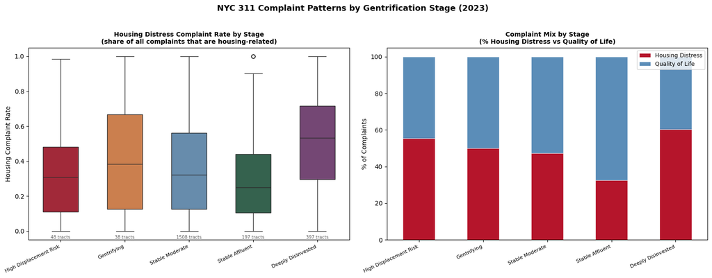

```
Saved: complaints_by_stage.png
```

## 32. TF-IDF Terms and Word Clouds

This section uses TF-IDF and word clouds to identify recurring and distinctive complaint terms by gentrification stage. TF-IDF highlights terms that are relatively more distinctive within each stage, while the word clouds provide a descriptive visualization of common complaint language.

These visuals should be interpreted as exploratory text analysis. They support the broader interpretation of complaint patterns but are not the primary statistical evidence.

```
=== TF-IDF: Most Distinctive Complaint Terms by Stage ===
  High Displacement Risk: water | heat hot | heat | hot water | hot | water apartment | apartment | apartment heat
  Gentrifying: parking | water | heat | heat hot | hot | hot water | entire building | water entire
  Stable Moderate: water | heat hot | heat | hot water | hot | parking | building | water entire
  Stable Affluent: parking | illegal | illegal parking | blocked | water | heat hot | heat | hot water
  Deeply Disinvested: water | heat hot | heat | hot water | hot | water entire | entire building | entire
```

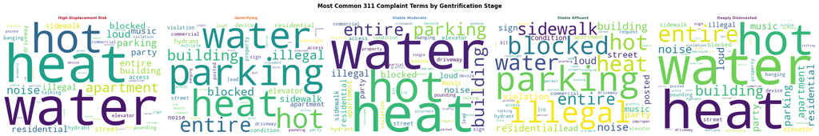

```
Saved: complaints_wordclouds_by_stage.png
```

## 33. Final Results Summary

This section prints the core project results in one place: network size, Kruskal-Wallis results, stage means for in-degree and out-degree centrality, interpretation, limitations, and scope.

The main interpretation is that out-degree centrality is the most relevant network measure for this research question. In-degree centrality identifies destination hubs, while out-degree centrality captures how broadly residents commute outward from their home tracts.

```
=== FINAL PROJECT SUMMARY ===

NETWORK
  Nodes:           2325 census tracts (5 NYC boroughs)
  Edges:           985,216 directed tract-to-tract flows
  Graph density:   0.1823
  Total commuters: 2,826,641

KRUSKAL-WALLIS RESULTS
  In-Degree Centrality           p = 0.0015  Significant: YES
  Out-Degree Centrality          p = 0.0000  Significant: YES
  Eigenvector Centrality         p = 0.0000  Significant: YES
  Weighted In-Strength           p = 0.0025  Significant: YES
  Weighted Out-Strength          p = 0.0019  Significant: YES

STAGE MEANS (in-degree vs out-degree)
                        in_degree_centrality  out_degree_centrality
gentrification_stage
Deeply Disinvested                    0.1771                 0.2054
Gentrifying                           0.2466                 0.1720
High Displacement Risk                0.1630                 0.1841
Stable Affluent                       0.2292                 0.1734
Stable Moderate                       0.1774                 0.1876
Unknown                               0.1729                 0.0691

INTERPRETATION
  Out-degree centrality is the measure most likely to show stage differences.
  Consistent with Project 1: displacement pressure shows up in commuting dispersion,
  not hub-peripheral position.

WHAT THE DATA CANNOT TELL US
  Correlation only -- not causation.
  Does not capture why residents commute broadly (job type, transit, wages).

SCOPE
  NYC-internal commuting only. NJ, Westchester, Long Island excluded.
  Gentrification stage = 2021 ACS cross-section, not time-series.
```

## Conclusion and Interpretation

The results indicate that gentrification and displacement pressure relate to commuting-network position, but not through a simple hub-versus-periphery pattern. In-degree centrality is most useful for identifying employment and institutional destinations, while out-degree centrality is more useful for understanding residential commuting dispersion.

The strongest network finding is that deeply disinvested tracts show broader outbound commuting patterns. This suggests that residents in these tracts are connected to a wider range of work destinations across the city. The 311 complaint analysis adds a second layer of evidence by showing that housing distress complaints are more prominent in deeply disinvested and high displacement risk tracts than in stable affluent tracts.

Overall, the project suggests that displacement and disinvestment are not only housing issues. They can also appear in mobility patterns, complaint language, transit access, and neighborhood conditions. The main takeaway is that outward commuting dispersion can serve as a network-based signal of urban inequality when interpreted alongside housing distress complaints and supplemental neighborhood indicators.

## Limitations

This analysis is observational and does not establish causation. The results show associations between gentrification stage, commuting network position, and 311 complaint patterns, but they do not prove that gentrification directly causes commuting dispersion or housing distress.

The gentrification classification is based primarily on ACS indicators and should be treated as an analytical framework rather than an official designation. A stronger gentrification model would compare neighborhood change over a longer period, such as 2010 to 2021, and would incorporate additional measures of housing market change, demographic change, eviction pressure, and development activity.

The commuting network includes only NYC-internal flows. Commutes to New Jersey, Long Island, Westchester, and other regional destinations are excluded. Finally, 311 data reflects reported complaints rather than all underlying neighborhood conditions. Reporting behavior may vary by neighborhood, language access, tenant awareness, and trust in city systems.

## References and Data Sources

- U.S. Census Bureau. LEHD Origin-Destination Employment Statistics (LODES), 2021.
- U.S. Census Bureau. American Community Survey 5-Year Estimates, 2015 and 2021.
- NYC Open Data. 311 Service Requests, NYCHA Public Housing Developments, and PLUTO data.
- NYC Department of City Planning. Census Tract to NTA relationship file.
- MTA Subway Station Location Data.
- Network analysis concepts follow standard graph-theoretic interpretations of directed degree, weighted strength, and eigenvector centrality.

## 34. Optional Report Export

This optional cell attempts to export the notebook to an HTML report. If Quarto is unavailable or fails, the code falls back to Jupyter `nbconvert`. If the export fails, the notebook itself can still be submitted because the assignment accepts reproducible notebook formats.

```
Installing Quarto...
Quarto available: True

Report ready: FinalProject_Submission_Report.html (4.0 MB)
```

FinalProject_Submission_Report.html

## 35. Colab Save and Download Helper

This final utility cell saves the live Colab notebook and exports an HTML version without code input. It is included for submission convenience and does not affect the analysis.